# DATA Analyzing for Ford GoBike

#### by. hamed bintalib

Ford GoBike is the Bay Area's bike share system. Bay Area Bike Share was introduced in 2013 as a pilot program for the region, with 700 bikes and 70 stations across San Francisco and San Jose. By the end of 2018, Ford GoBike will grow to 7,000 bikes across San Francisco, the East Bay and San Jose.

```python
import numpy as np
import pandas as pd
import matplotlib.pyplot as plt
import seaborn as sb
%matplotlib inline
```

```python
df= pd.read_csv('201904-fordgobike-tripdata.csv')
```

```python
df.head()
```

|  | duration_sec | start_time | end_time | start_station_id | start_station_name | start_station_latitude | start_station_longitude | end_station_id | end_station_name | end_station_latitude | end_station_longitude | bike_id | user_type | member_birth_year | member_gender | bike_share_for_all_trip |
| --- | --- | --- | --- | --- | --- | --- | --- | --- | --- | --- | --- | --- | --- | --- | --- | --- |
| 0 | 50305 | 2019-04-30 22:33:55.1550 | 2019-05-01 12:32:20.4540 | 368.0 | Myrtle St at Polk St | 37.785434 | -122.419622 | 324.0 | Union Square (Powell St at Post St) | 37.788300 | -122.408531 | 2749 | Subscriber | 1989.0 | Female | No |
| 1 | 53725 | 2019-04-30 20:43:41.6320 | 2019-05-01 11:39:06.9170 | 246.0 | Berkeley Civic Center | 37.869060 | -122.270556 | 241.0 | Ashby BART Station | 37.852477 | -122.270213 | 2608 | Customer | NaN | NaN | No |
| 2 | 78072 | 2019-04-30 10:32:46.4890 | 2019-05-01 08:13:58.9750 | 64.0 | 5th St at Brannan St | 37.776754 | -122.399018 | 64.0 | 5th St at Brannan St | 37.776754 | -122.399018 | 258 | Subscriber | 1993.0 | Male | No |
| 3 | 78969 | 2019-04-30 10:00:51.5500 | 2019-05-01 07:57:01.2620 | 67.0 | San Francisco Caltrain Station 2 (Townsend St... | 37.776639 | -122.395526 | 89.0 | Division St at Potrero Ave | 37.769218 | -122.407646 | 1974 | Subscriber | 1972.0 | Male | No |
| 4 | 1128 | 2019-04-30 23:59:04.7390 | 2019-05-01 00:17:53.0910 | 124.0 | 19th St at Florida St | 37.760447 | -122.410807 | 5.0 | Powell St BART Station (Market St at 5th St) | 37.783899 | -122.408445 | 877 | Subscriber | 1973.0 | Male | No |

```python
df.isnull().sum()
```

```
duration_sec                   0
start_time                     0
end_time                       0
start_station_id              64
start_station_name            64
start_station_latitude         0
start_station_longitude        0
end_station_id                64
end_station_name              64
end_station_latitude           0
end_station_longitude          0
bike_id                        0
user_type                      0
member_birth_year          11199
member_gender              11199
bike_share_for_all_trip        0
dtype: int64
```

```python
df[df['start_station_id'].isnull()]
```

|  | duration_sec | start_time | end_time | start_station_id | start_station_name | start_station_latitude | start_station_longitude | end_station_id | end_station_name | end_station_latitude | end_station_longitude | bike_id | user_type | member_birth_year | member_gender | bike_share_for_all_trip |
| --- | --- | --- | --- | --- | --- | --- | --- | --- | --- | --- | --- | --- | --- | --- | --- | --- |
| 10983 | 1131 | 2019-04-29 15:30:48.3890 | 2019-04-29 15:49:39.4800 | NaN | NaN | 37.41 | -121.95 | NaN | NaN | 37.42 | -121.96 | 4106 | Customer | 1979.0 | Female | No |
| 11568 | 268 | 2019-04-29 13:12:08.9280 | 2019-04-29 13:16:37.8740 | NaN | NaN | 37.41 | -121.94 | NaN | NaN | 37.41 | -121.94 | 4106 | Customer | 1991.0 | Male | No |
| 14814 | 669 | 2019-04-28 23:02:16.2860 | 2019-04-28 23:13:25.6670 | NaN | NaN | 37.40 | -121.95 | NaN | NaN | 37.40 | -121.94 | 4285 | Customer | 1989.0 | Female | No |
| 16067 | 94 | 2019-04-28 16:30:12.3680 | 2019-04-28 16:31:46.8660 | NaN | NaN | 37.40 | -121.95 | NaN | NaN | 37.40 | -121.95 | 4285 | Customer | 1986.0 | Male | No |
| 17179 | 2389 | 2019-04-28 12:24:07.6830 | 2019-04-28 13:03:57.4710 | NaN | NaN | 37.40 | -121.94 | NaN | NaN | 37.40 | -121.94 | 4244 | Customer | 1966.0 | Female | No |
| 17185 | 185 | 2019-04-28 12:59:44.6410 | 2019-04-28 13:02:49.7770 | NaN | NaN | 37.42 | -121.94 | NaN | NaN | 37.42 | -121.94 | 4106 | Customer | 1997.0 | Other | No |
| 18116 | 719 | 2019-04-28 09:38:14.0730 | 2019-04-28 09:50:13.5640 | NaN | NaN | 37.41 | -121.93 | NaN | NaN | 37.40 | -121.95 | 4285 | Customer | 1993.0 | Male | No |
| 18475 | 751 | 2019-04-28 00:07:43.9860 | 2019-04-28 00:20:15.8870 | NaN | NaN | 37.40 | -121.93 | NaN | NaN | 37.41 | -121.93 | 4285 | Customer | 1992.0 | Female | No |
| 18835 | 212 | 2019-04-27 20:37:19.9790 | 2019-04-27 20:40:52.7780 | NaN | NaN | 37.41 | -121.95 | NaN | NaN | 37.42 | -121.94 | 4106 | Customer | 1997.0 | Other | No |
| 18858 | 227 | 2019-04-27 20:26:21.5780 | 2019-04-27 20:30:08.7800 | NaN | NaN | 37.41 | -121.95 | NaN | NaN | 37.41 | -121.95 | 4106 | Customer | 1997.0 | Other | No |
| 19089 | 8701 | 2019-04-27 16:57:03.7660 | 2019-04-27 19:22:05.4790 | NaN | NaN | 37.41 | -121.94 | NaN | NaN | 37.40 | -121.94 | 4244 | Customer | 1986.0 | Female | No |
| 20087 | 562 | 2019-04-27 16:04:22.4800 | 2019-04-27 16:13:44.6700 | NaN | NaN | 37.40 | -121.94 | NaN | NaN | 37.40 | -121.93 | 4285 | Customer | 1993.0 | Female | No |
| 20353 | 565 | 2019-04-27 15:22:59.6910 | 2019-04-27 15:32:25.4820 | NaN | NaN | 37.40 | -121.93 | NaN | NaN | 37.40 | -121.94 | 4285 | Customer | 1993.0 | Female | No |
| 20528 | 1492 | 2019-04-27 14:37:05.1770 | 2019-04-27 15:01:57.7680 | NaN | NaN | 37.40 | -121.94 | NaN | NaN | 37.39 | -121.93 | 4098 | Customer | 1976.0 | Male | No |
| 21994 | 1275 | 2019-04-27 10:21:35.5790 | 2019-04-27 10:42:51.2790 | NaN | NaN | 37.40 | -121.95 | NaN | NaN | 37.40 | -121.94 | 4098 | Customer | 1975.0 | Male | No |
| 23713 | 291 | 2019-04-26 19:11:09.4810 | 2019-04-26 19:16:01.1860 | NaN | NaN | 37.39 | -121.95 | NaN | NaN | 37.40 | -121.95 | 4098 | Customer | 1981.0 | Male | No |
| 27056 | 667 | 2019-04-26 12:32:42.5700 | 2019-04-26 12:43:49.9820 | NaN | NaN | 37.39 | -121.94 | NaN | NaN | 37.40 | -121.93 | 4285 | Subscriber | 1986.0 | Male | No |
| 29583 | 256 | 2019-04-26 07:41:33.5820 | 2019-04-26 07:45:50.1810 | NaN | NaN | 37.40 | -121.95 | NaN | NaN | 37.40 | -121.95 | 4098 | Customer | 1981.0 | Male | No |
| 30771 | 1748 | 2019-04-25 19:34:16.2770 | 2019-04-25 20:03:24.8880 | NaN | NaN | 37.39 | -121.94 | NaN | NaN | 37.39 | -121.94 | 4285 | Customer | 1982.0 | Male | No |
| 30992 | 1601 | 2019-04-25 19:05:43.8780 | 2019-04-25 19:32:25.5250 | NaN | NaN | 37.41 | -121.94 | NaN | NaN | 37.39 | -121.94 | 4285 | Customer | 1982.0 | Male | No |
| 34042 | 1894 | 2019-04-25 13:03:54.8000 | 2019-04-25 13:35:29.1180 | NaN | NaN | 37.41 | -121.94 | NaN | NaN | 37.41 | -121.94 | 4285 | Customer | 1990.0 | Female | No |
| 38147 | 2607 | 2019-04-24 19:37:20.0940 | 2019-04-24 20:20:47.2660 | NaN | NaN | 37.38 | -121.94 | NaN | NaN | 37.41 | -121.94 | 4285 | Customer | 1982.0 | Male | No |
| 45968 | 1221 | 2019-04-23 20:00:26.8720 | 2019-04-23 20:20:48.2670 | NaN | NaN | 37.41 | -121.95 | NaN | NaN | 37.38 | -121.94 | 4285 | Customer | 1995.0 | Male | No |
| 46876 | 13239 | 2019-04-23 15:03:41.7770 | 2019-04-23 18:44:21.7710 | NaN | NaN | 37.40 | -121.95 | NaN | NaN | 37.41 | -121.95 | 4285 | Subscriber | 1977.0 | Male | No |
| 55314 | 278 | 2019-04-22 17:50:53.7700 | 2019-04-22 17:55:32.0650 | NaN | NaN | 37.40 | -121.95 | NaN | NaN | 37.40 | -121.95 | 4098 | Customer | 1981.0 | Male | No |
| 61170 | 1025 | 2019-04-21 18:44:50.5840 | 2019-04-21 19:01:55.8870 | NaN | NaN | 37.40 | -121.95 | NaN | NaN | 37.40 | -121.93 | 4211 | Customer | 1992.0 | Male | No |
| 61227 | 1792 | 2019-04-21 18:17:46.7830 | 2019-04-21 18:47:39.1710 | NaN | NaN | 37.40 | -121.92 | NaN | NaN | 37.40 | -121.95 | 4098 | Customer | 1993.0 | Male | No |
| 61228 | 1582 | 2019-04-21 18:21:03.9840 | 2019-04-21 18:47:26.4830 | NaN | NaN | 37.40 | -121.92 | NaN | NaN | 37.40 | -121.95 | 4285 | Customer | 1993.0 | Male | No |
| 61566 | 1166 | 2019-04-21 17:15:37.2800 | 2019-04-21 17:35:03.5790 | NaN | NaN | 37.42 | -121.96 | NaN | NaN | 37.40 | -121.95 | 4211 | Customer | 1992.0 | Male | No |
| 61680 | 872 | 2019-04-21 16:57:17.0910 | 2019-04-21 17:11:49.2810 | NaN | NaN | 37.41 | -121.93 | NaN | NaN | 37.42 | -121.95 | 4211 | Customer | 1992.0 | Male | No |
| ... | ... | ... | ... | ... | ... | ... | ... | ... | ... | ... | ... | ... | ... | ... | ... | ... |
| 66787 | 775 | 2019-04-20 11:31:49.4760 | 2019-04-20 11:44:44.8770 | NaN | NaN | 37.40 | -121.95 | NaN | NaN | 37.40 | -121.93 | 4211 | Customer | 1992.0 | Male | No |
| 66810 | 1484 | 2019-04-20 11:14:25.5730 | 2019-04-20 11:39:09.9710 | NaN | NaN | 37.40 | -121.94 | NaN | NaN | 37.40 | -121.94 | 4098 | Customer | 1968.0 | Female | No |
| 67032 | 1129 | 2019-04-20 10:39:58.1190 | 2019-04-20 10:58:47.3820 | NaN | NaN | 37.40 | -121.93 | NaN | NaN | 37.40 | -121.95 | 4211 | Customer | 1992.0 | Male | No |
| 67482 | 1445 | 2019-04-20 08:19:27.3710 | 2019-04-20 08:43:32.9730 | NaN | NaN | 37.40 | -121.92 | NaN | NaN | 37.40 | -121.94 | 4098 | Customer | 1986.0 | Male | No |
| 93758 | 324 | 2019-04-16 14:05:41.5690 | 2019-04-16 14:11:05.7930 | NaN | NaN | 37.40 | -121.93 | NaN | NaN | 37.40 | -121.93 | 4211 | Subscriber | 1986.0 | Male | No |
| 111649 | 2455 | 2019-04-13 13:02:46.9230 | 2019-04-13 13:43:41.9410 | NaN | NaN | 37.40 | -121.94 | NaN | NaN | 37.40 | -121.93 | 4211 | Customer | 1983.0 | Male | No |
| 116701 | 1388 | 2019-04-12 19:00:58.7710 | 2019-04-12 19:24:07.4900 | NaN | NaN | 37.41 | -121.93 | NaN | NaN | 37.40 | -121.92 | 4098 | Customer | 1980.0 | Male | No |
| 116718 | 1781 | 2019-04-12 18:53:13.8580 | 2019-04-12 19:22:55.2330 | NaN | NaN | 37.40 | -121.93 | NaN | NaN | 37.40 | -121.92 | 4285 | Customer | 1980.0 | Female | No |
| 116807 | 1422 | 2019-04-12 18:54:09.0930 | 2019-04-12 19:17:51.2720 | NaN | NaN | 37.40 | -121.94 | NaN | NaN | 37.40 | -121.94 | 4211 | Customer | 1994.0 | Male | No |
| 118404 | 434 | 2019-04-12 17:48:06.5790 | 2019-04-12 17:55:21.3350 | NaN | NaN | 37.40 | -121.92 | NaN | NaN | 37.40 | -121.93 | 4285 | Customer | 1997.0 | Male | No |
| 118594 | 410 | 2019-04-12 17:39:28.1740 | 2019-04-12 17:46:18.5530 | NaN | NaN | 37.41 | -121.93 | NaN | NaN | 37.40 | -121.92 | 4285 | Customer | 1997.0 | Male | No |
| 119169 | 610 | 2019-04-12 17:10:55.3770 | 2019-04-12 17:21:05.7270 | NaN | NaN | 37.38 | -121.94 | NaN | NaN | 37.39 | -121.93 | 4164 | Subscriber | 1989.0 | Female | No |
| 119690 | 1920 | 2019-04-12 16:26:12.3300 | 2019-04-12 16:58:12.6710 | NaN | NaN | 37.39 | -121.93 | NaN | NaN | 37.38 | -121.94 | 4164 | Subscriber | 1987.0 | Male | No |
| 122589 | 267 | 2019-04-12 12:28:03.4720 | 2019-04-12 12:32:31.3730 | NaN | NaN | 37.41 | -121.93 | NaN | NaN | 37.41 | -121.93 | 4285 | Subscriber | 1996.0 | Male | No |
| 124938 | 817 | 2019-04-12 08:47:31.6750 | 2019-04-12 09:01:09.3320 | NaN | NaN | 37.40 | -121.93 | NaN | NaN | 37.39 | -121.93 | 4164 | Customer | 1993.0 | Male | No |
| 131384 | 633 | 2019-04-11 17:29:51.6740 | 2019-04-11 17:40:25.0750 | NaN | NaN | 37.39 | -121.93 | NaN | NaN | 37.40 | -121.93 | 4098 | Subscriber | 1983.0 | Male | No |
| 148369 | 432 | 2019-04-10 09:46:00.5730 | 2019-04-10 09:53:12.9580 | NaN | NaN | 37.40 | -121.94 | NaN | NaN | 37.39 | -121.93 | 4098 | Subscriber | 1986.0 | Male | No |
| 159974 | 601 | 2019-04-09 10:50:05.0850 | 2019-04-09 11:00:06.5740 | NaN | NaN | 37.41 | -121.95 | NaN | NaN | 37.41 | -121.95 | 4107 | Subscriber | 1992.0 | Male | Yes |
| 175807 | 108 | 2019-04-07 19:26:56.5620 | 2019-04-07 19:28:44.9910 | NaN | NaN | 37.40 | -121.94 | NaN | NaN | 37.40 | -121.94 | 4211 | Customer | 1987.0 | Female | No |
| 176448 | 1276 | 2019-04-07 17:56:20.5500 | 2019-04-07 18:17:36.6280 | NaN | NaN | 37.40 | -121.93 | NaN | NaN | 37.40 | -121.94 | 4211 | Subscriber | 1988.0 | Male | No |
| 200310 | 1041 | 2019-04-04 18:33:16.8310 | 2019-04-04 18:50:37.8710 | NaN | NaN | 37.36 | -121.89 | NaN | NaN | 37.36 | -121.89 | 4093 | Customer | 2001.0 | Male | No |
| 221529 | 1342 | 2019-04-02 19:08:43.6910 | 2019-04-02 19:31:06.6260 | NaN | NaN | 37.40 | -121.93 | NaN | NaN | 37.40 | -121.92 | 4211 | Customer | 1989.0 | Male | No |
| 222061 | 1132 | 2019-04-02 18:30:33.0320 | 2019-04-02 18:49:25.4340 | NaN | NaN | 37.41 | -121.93 | NaN | NaN | 37.41 | -121.94 | 4085 | Customer | 1994.0 | Male | No |
| 222458 | 1241 | 2019-04-02 18:05:53.0930 | 2019-04-02 18:26:34.3630 | NaN | NaN | 37.41 | -121.95 | NaN | NaN | 37.41 | -121.95 | 4107 | Customer | 1994.0 | Male | No |
| 224405 | 1403 | 2019-04-02 16:33:41.3320 | 2019-04-02 16:57:04.4700 | NaN | NaN | 37.40 | -121.93 | NaN | NaN | 37.36 | -121.89 | 4093 | Customer | 1962.0 | Male | No |
| 226208 | 681 | 2019-04-02 12:27:15.5310 | 2019-04-02 12:38:36.9320 | NaN | NaN | 37.39 | -121.93 | NaN | NaN | 37.40 | -121.93 | 4211 | Subscriber | 1986.0 | Male | No |
| 230020 | 4803 | 2019-04-01 19:03:07.4730 | 2019-04-01 20:23:10.7310 | NaN | NaN | 37.40 | -121.93 | NaN | NaN | 37.40 | -121.94 | 4270 | Customer | 1995.0 | Male | No |
| 232901 | 13460 | 2019-04-01 13:42:15.0730 | 2019-04-01 17:26:35.8950 | NaN | NaN | 37.41 | -121.95 | NaN | NaN | 37.40 | -121.94 | 4098 | Customer | 1991.0 | Male | No |
| 234606 | 229 | 2019-04-01 13:17:14.5670 | 2019-04-01 13:21:03.9410 | NaN | NaN | 37.41 | -121.94 | NaN | NaN | 37.41 | -121.94 | 4098 | Customer | 1991.0 | Male | No |
| 238139 | 647 | 2019-04-01 07:50:49.5360 | 2019-04-01 08:01:37.2420 | NaN | NaN | 37.40 | -121.93 | NaN | NaN | 37.39 | -121.93 | 4211 | Subscriber | 1983.0 | Male | No |

64 rows × 16 columns

```python
df.info()
```

```
<class 'pandas.core.frame.DataFrame'>
RangeIndex: 239111 entries, 0 to 239110
Data columns (total 16 columns):
duration_sec               239111 non-null int64
start_time                 239111 non-null object
end_time                   239111 non-null object
start_station_id           239047 non-null float64
start_station_name         239047 non-null object
start_station_latitude     239111 non-null float64
start_station_longitude    239111 non-null float64
end_station_id             239047 non-null float64
end_station_name           239047 non-null object
end_station_latitude       239111 non-null float64
end_station_longitude      239111 non-null float64
bike_id                    239111 non-null int64
user_type                  239111 non-null object
member_birth_year          227912 non-null float64
member_gender              227912 non-null object
bike_share_for_all_trip    239111 non-null object
dtypes: float64(7), int64(2), object(7)
memory usage: 29.2+ MB
```

```python
df.describe()
```

|  | duration_sec | start_station_id | start_station_latitude | start_station_longitude | end_station_id | end_station_latitude | end_station_longitude | bike_id | member_birth_year |
| --- | --- | --- | --- | --- | --- | --- | --- | --- | --- |
| count | 239111.000000 | 239047.000000 | 239111.000000 | 239111.000000 | 239047.000000 | 239111.000000 | 239111.000000 | 239111.000000 | 227912.000000 |
| mean | 802.671199 | 141.836538 | 37.769536 | -122.352503 | 140.838099 | 37.766996 | -122.343420 | 3666.956493 | 1984.863250 |
| std | 1990.006091 | 116.289776 | 0.127698 | 0.277088 | 116.386168 | 0.343083 | 1.068144 | 2180.717333 | 9.953144 |
| min | 61.000000 | 3.000000 | 0.000000 | -122.453704 | 3.000000 | 0.000000 | -122.453704 | 11.000000 | 1878.000000 |
| 25% | 349.000000 | 47.000000 | 37.770083 | -122.413004 | 44.000000 | 37.770407 | -122.411738 | 1720.000000 | 1980.000000 |
| 50% | 558.000000 | 104.000000 | 37.780760 | -122.398285 | 102.000000 | 37.780955 | -122.397437 | 3471.000000 | 1987.000000 |
| 75% | 876.000000 | 240.000000 | 37.797280 | -122.291209 | 239.000000 | 37.797320 | -122.291376 | 5749.000000 | 1992.000000 |
| max | 86114.000000 | 420.000000 | 37.880222 | 0.000000 | 420.000000 | 37.880222 | 0.000000 | 7108.000000 | 2001.000000 |

```python
#removing missing values in gender
df_clean=df[df['member_gender'].isnull()==False]
```

```python
df_clean.head()
```

|  | duration_sec | start_time | end_time | start_station_id | start_station_name | start_station_latitude | start_station_longitude | end_station_id | end_station_name | end_station_latitude | end_station_longitude | bike_id | user_type | member_birth_year | member_gender | bike_share_for_all_trip |
| --- | --- | --- | --- | --- | --- | --- | --- | --- | --- | --- | --- | --- | --- | --- | --- | --- |
| 0 | 50305 | 2019-04-30 22:33:55.1550 | 2019-05-01 12:32:20.4540 | 368.0 | Myrtle St at Polk St | 37.785434 | -122.419622 | 324.0 | Union Square (Powell St at Post St) | 37.788300 | -122.408531 | 2749 | Subscriber | 1989.0 | Female | No |
| 2 | 78072 | 2019-04-30 10:32:46.4890 | 2019-05-01 08:13:58.9750 | 64.0 | 5th St at Brannan St | 37.776754 | -122.399018 | 64.0 | 5th St at Brannan St | 37.776754 | -122.399018 | 258 | Subscriber | 1993.0 | Male | No |
| 3 | 78969 | 2019-04-30 10:00:51.5500 | 2019-05-01 07:57:01.2620 | 67.0 | San Francisco Caltrain Station 2 (Townsend St... | 37.776639 | -122.395526 | 89.0 | Division St at Potrero Ave | 37.769218 | -122.407646 | 1974 | Subscriber | 1972.0 | Male | No |
| 4 | 1128 | 2019-04-30 23:59:04.7390 | 2019-05-01 00:17:53.0910 | 124.0 | 19th St at Florida St | 37.760447 | -122.410807 | 5.0 | Powell St BART Station (Market St at 5th St) | 37.783899 | -122.408445 | 877 | Subscriber | 1973.0 | Male | No |
| 5 | 1388 | 2019-04-30 23:53:05.9820 | 2019-05-01 00:16:14.3130 | 243.0 | Bancroft Way at College Ave | 37.869360 | -122.254337 | 247.0 | Fulton St at Bancroft Way | 37.867789 | -122.265896 | 3234 | Customer | 1997.0 | Male | No |

```python
df_clean.info()
```

```
<class 'pandas.core.frame.DataFrame'>
Int64Index: 227912 entries, 0 to 239110
Data columns (total 16 columns):
duration_sec               227912 non-null int64
start_time                 227912 non-null object
end_time                   227912 non-null object
start_station_id           227848 non-null float64
start_station_name         227848 non-null object
start_station_latitude     227912 non-null float64
start_station_longitude    227912 non-null float64
end_station_id             227848 non-null float64
end_station_name           227848 non-null object
end_station_latitude       227912 non-null float64
end_station_longitude      227912 non-null float64
bike_id                    227912 non-null int64
user_type                  227912 non-null object
member_birth_year          227912 non-null float64
member_gender              227912 non-null object
bike_share_for_all_trip    227912 non-null object
dtypes: float64(7), int64(2), object(7)
memory usage: 29.6+ MB
```

```python
df.info()
```

```
<class 'pandas.core.frame.DataFrame'>
RangeIndex: 239111 entries, 0 to 239110
Data columns (total 16 columns):
duration_sec               239111 non-null int64
start_time                 239111 non-null object
end_time                   239111 non-null object
start_station_id           239047 non-null float64
start_station_name         239047 non-null object
start_station_latitude     239111 non-null float64
start_station_longitude    239111 non-null float64
end_station_id             239047 non-null float64
end_station_name           239047 non-null object
end_station_latitude       239111 non-null float64
end_station_longitude      239111 non-null float64
bike_id                    239111 non-null int64
user_type                  239111 non-null object
member_birth_year          227912 non-null float64
member_gender              227912 non-null object
bike_share_for_all_trip    239111 non-null object
dtypes: float64(7), int64(2), object(7)
memory usage: 29.2+ MB
```

```python
df_clean['member_gender'].value_counts()
```

```
Male      168140
Female     55498
Other       4274
Name: member_gender, dtype: int64
```

```python
df_clean['user_type'].value_counts()
```

```
Subscriber    198510
Customer       29402
Name: user_type, dtype: int64
```

```python
df_clean['start_station_id'].isnull().sum()
```

```
64
```

```python
# Removing missing values
df_clean=df_clean[df_clean['start_station_id'].isnull()==False]
```

```python
df_clean.info()
```

```
<class 'pandas.core.frame.DataFrame'>
Int64Index: 227848 entries, 0 to 239110
Data columns (total 16 columns):
duration_sec               227848 non-null int64
start_time                 227848 non-null object
end_time                   227848 non-null object
start_station_id           227848 non-null float64
start_station_name         227848 non-null object
start_station_latitude     227848 non-null float64
start_station_longitude    227848 non-null float64
end_station_id             227848 non-null float64
end_station_name           227848 non-null object
end_station_latitude       227848 non-null float64
end_station_longitude      227848 non-null float64
bike_id                    227848 non-null int64
user_type                  227848 non-null object
member_birth_year          227848 non-null float64
member_gender              227848 non-null object
bike_share_for_all_trip    227848 non-null object
dtypes: float64(7), int64(2), object(7)
memory usage: 29.6+ MB
```

```python
df_clean.isnull().sum()
```

```
duration_sec               0
start_time                 0
end_time                   0
start_station_id           0
start_station_name         0
start_station_latitude     0
start_station_longitude    0
end_station_id             0
end_station_name           0
end_station_latitude       0
end_station_longitude      0
bike_id                    0
user_type                  0
member_birth_year          0
member_gender              0
bike_share_for_all_trip    0
dtype: int64
```

```python
df_clean['start_station_id'].isnull().sum()
```

```
0
```

```python
df_clean.duplicated().sum()
```

```
0
```

```python
df_clean.info()
```

```
<class 'pandas.core.frame.DataFrame'>
Int64Index: 227848 entries, 0 to 239110
Data columns (total 16 columns):
duration_sec               227848 non-null int64
start_time                 227848 non-null object
end_time                   227848 non-null object
start_station_id           227848 non-null float64
start_station_name         227848 non-null object
start_station_latitude     227848 non-null float64
start_station_longitude    227848 non-null float64
end_station_id             227848 non-null float64
end_station_name           227848 non-null object
end_station_latitude       227848 non-null float64
end_station_longitude      227848 non-null float64
bike_id                    227848 non-null int64
user_type                  227848 non-null object
member_birth_year          227848 non-null float64
member_gender              227848 non-null object
bike_share_for_all_trip    227848 non-null object
dtypes: float64(7), int64(2), object(7)
memory usage: 29.6+ MB
```

```python
# Changing start_time and end_time to datetime format
df_clean.start_time = pd.to_datetime(df_clean.start_time)
df_clean.end_time = pd.to_datetime(df_clean.end_time)
```

```python
df_clean.head()
```

|  | duration_sec | start_time | end_time | start_station_id | start_station_name | start_station_latitude | start_station_longitude | end_station_id | end_station_name | end_station_latitude | end_station_longitude | bike_id | user_type | member_birth_year | member_gender | bike_share_for_all_trip |
| --- | --- | --- | --- | --- | --- | --- | --- | --- | --- | --- | --- | --- | --- | --- | --- | --- |
| 0 | 50305 | 2019-04-30 22:33:55.155 | 2019-05-01 12:32:20.454 | 368.0 | Myrtle St at Polk St | 37.785434 | -122.419622 | 324.0 | Union Square (Powell St at Post St) | 37.788300 | -122.408531 | 2749 | Subscriber | 1989.0 | Female | No |
| 2 | 78072 | 2019-04-30 10:32:46.489 | 2019-05-01 08:13:58.975 | 64.0 | 5th St at Brannan St | 37.776754 | -122.399018 | 64.0 | 5th St at Brannan St | 37.776754 | -122.399018 | 258 | Subscriber | 1993.0 | Male | No |
| 3 | 78969 | 2019-04-30 10:00:51.550 | 2019-05-01 07:57:01.262 | 67.0 | San Francisco Caltrain Station 2 (Townsend St... | 37.776639 | -122.395526 | 89.0 | Division St at Potrero Ave | 37.769218 | -122.407646 | 1974 | Subscriber | 1972.0 | Male | No |
| 4 | 1128 | 2019-04-30 23:59:04.739 | 2019-05-01 00:17:53.091 | 124.0 | 19th St at Florida St | 37.760447 | -122.410807 | 5.0 | Powell St BART Station (Market St at 5th St) | 37.783899 | -122.408445 | 877 | Subscriber | 1973.0 | Male | No |
| 5 | 1388 | 2019-04-30 23:53:05.982 | 2019-05-01 00:16:14.313 | 243.0 | Bancroft Way at College Ave | 37.869360 | -122.254337 | 247.0 | Fulton St at Bancroft Way | 37.867789 | -122.265896 | 3234 | Customer | 1997.0 | Male | No |

```python
#Extract dayofweek, hours information from the start_time
df_clean['start_time_dayofweek']= df_clean['start_time'].dt.strftime('%a')
df_clean['start_time_hour']= df_clean['start_time'].dt.hour
```

```python
df_clean['start_time_dayofweek'].value_counts()
```

```
Tue    41856
Mon    39296
Thu    37234
Wed    37222
Fri    33733
Sat    21475
Sun    17032
Name: start_time_dayofweek, dtype: int64
```

```python
df_clean.info()
```

```
<class 'pandas.core.frame.DataFrame'>
Int64Index: 227848 entries, 0 to 239110
Data columns (total 18 columns):
duration_sec               227848 non-null int64
start_time                 227848 non-null datetime64[ns]
end_time                   227848 non-null datetime64[ns]
start_station_id           227848 non-null float64
start_station_name         227848 non-null object
start_station_latitude     227848 non-null float64
start_station_longitude    227848 non-null float64
end_station_id             227848 non-null float64
end_station_name           227848 non-null object
end_station_latitude       227848 non-null float64
end_station_longitude      227848 non-null float64
bike_id                    227848 non-null int64
user_type                  227848 non-null object
member_birth_year          227848 non-null float64
member_gender              227848 non-null object
bike_share_for_all_trip    227848 non-null object
start_time_dayofweek       227848 non-null object
start_time_hour            227848 non-null int64
dtypes: datetime64[ns](2), float64(7), int64(3), object(6)
memory usage: 33.0+ MB
```

```python
df_clean.head()
```

|  | duration_sec | start_time | end_time | start_station_id | start_station_name | start_station_latitude | start_station_longitude | end_station_id | end_station_name | end_station_latitude | end_station_longitude | bike_id | user_type | member_birth_year | member_gender | bike_share_for_all_trip | start_time_dayofweek | start_time_hour |
| --- | --- | --- | --- | --- | --- | --- | --- | --- | --- | --- | --- | --- | --- | --- | --- | --- | --- | --- |
| 0 | 50305 | 2019-04-30 22:33:55.155 | 2019-05-01 12:32:20.454 | 368.0 | Myrtle St at Polk St | 37.785434 | -122.419622 | 324.0 | Union Square (Powell St at Post St) | 37.788300 | -122.408531 | 2749 | Subscriber | 1989.0 | Female | No | Tue | 22 |
| 2 | 78072 | 2019-04-30 10:32:46.489 | 2019-05-01 08:13:58.975 | 64.0 | 5th St at Brannan St | 37.776754 | -122.399018 | 64.0 | 5th St at Brannan St | 37.776754 | -122.399018 | 258 | Subscriber | 1993.0 | Male | No | Tue | 10 |
| 3 | 78969 | 2019-04-30 10:00:51.550 | 2019-05-01 07:57:01.262 | 67.0 | San Francisco Caltrain Station 2 (Townsend St... | 37.776639 | -122.395526 | 89.0 | Division St at Potrero Ave | 37.769218 | -122.407646 | 1974 | Subscriber | 1972.0 | Male | No | Tue | 10 |
| 4 | 1128 | 2019-04-30 23:59:04.739 | 2019-05-01 00:17:53.091 | 124.0 | 19th St at Florida St | 37.760447 | -122.410807 | 5.0 | Powell St BART Station (Market St at 5th St) | 37.783899 | -122.408445 | 877 | Subscriber | 1973.0 | Male | No | Tue | 23 |
| 5 | 1388 | 2019-04-30 23:53:05.982 | 2019-05-01 00:16:14.313 | 243.0 | Bancroft Way at College Ave | 37.869360 | -122.254337 | 247.0 | Fulton St at Bancroft Way | 37.867789 | -122.265896 | 3234 | Customer | 1997.0 | Male | No | Tue | 23 |

```python
df_clean['start_time_dayofweek'].value_counts()
```

```
Tue    41856
Mon    39296
Thu    37234
Wed    37222
Fri    33733
Sat    21475
Sun    17032
Name: start_time_dayofweek, dtype: int64
```

```python
# Convert the start_time_dayofweek to ordinal variables.
weekdays = ['Mon','Tue','Wed','Thu','Fri', 'Sat', 'Sun']
ordered_weekdays = pd.api.types.CategoricalDtype(ordered = True, categories = weekdays)
df_clean['start_time_dayofweek'] = df_clean['start_time_dayofweek'].astype(ordered_weekdays)
```

```python
df_clean.info()
```

```
<class 'pandas.core.frame.DataFrame'>
Int64Index: 227848 entries, 0 to 239110
Data columns (total 18 columns):
duration_sec               227848 non-null int64
start_time                 227848 non-null datetime64[ns]
end_time                   227848 non-null datetime64[ns]
start_station_id           227848 non-null float64
start_station_name         227848 non-null object
start_station_latitude     227848 non-null float64
start_station_longitude    227848 non-null float64
end_station_id             227848 non-null float64
end_station_name           227848 non-null object
end_station_latitude       227848 non-null float64
end_station_longitude      227848 non-null float64
bike_id                    227848 non-null int64
user_type                  227848 non-null object
member_birth_year          227848 non-null float64
member_gender              227848 non-null object
bike_share_for_all_trip    227848 non-null object
start_time_dayofweek       227848 non-null category
start_time_hour            227848 non-null int64
dtypes: category(1), datetime64[ns](2), float64(7), int64(3), object(5)
memory usage: 31.5+ MB
```

```python
# identify the age of the customer from member_birth_year column.
df_clean['member_age'] = 2019 - df_clean['member_birth_year']
```

```python
df_clean['member_age'] = df_clean['member_age'].astype(int)
df_clean['member_birth_year'] = df_clean['member_birth_year'].astype(int)
```

```python
df_clean.info()
```

```
<class 'pandas.core.frame.DataFrame'>
Int64Index: 227848 entries, 0 to 239110
Data columns (total 19 columns):
duration_sec               227848 non-null int64
start_time                 227848 non-null datetime64[ns]
end_time                   227848 non-null datetime64[ns]
start_station_id           227848 non-null float64
start_station_name         227848 non-null object
start_station_latitude     227848 non-null float64
start_station_longitude    227848 non-null float64
end_station_id             227848 non-null float64
end_station_name           227848 non-null object
end_station_latitude       227848 non-null float64
end_station_longitude      227848 non-null float64
bike_id                    227848 non-null int64
user_type                  227848 non-null object
member_birth_year          227848 non-null int64
member_gender              227848 non-null object
bike_share_for_all_trip    227848 non-null object
start_time_dayofweek       227848 non-null category
start_time_hour            227848 non-null int64
member_age                 227848 non-null int64
dtypes: category(1), datetime64[ns](2), float64(6), int64(5), object(5)
memory usage: 33.2+ MB
```

```python
df_clean.head()
```

|  | duration_sec | start_time | end_time | start_station_id | start_station_name | start_station_latitude | start_station_longitude | end_station_id | end_station_name | end_station_latitude | end_station_longitude | bike_id | user_type | member_birth_year | member_gender | bike_share_for_all_trip | start_time_dayofweek | start_time_hour | member_age |
| --- | --- | --- | --- | --- | --- | --- | --- | --- | --- | --- | --- | --- | --- | --- | --- | --- | --- | --- | --- |
| 0 | 50305 | 2019-04-30 22:33:55.155 | 2019-05-01 12:32:20.454 | 368.0 | Myrtle St at Polk St | 37.785434 | -122.419622 | 324.0 | Union Square (Powell St at Post St) | 37.788300 | -122.408531 | 2749 | Subscriber | 1989 | Female | No | Tue | 22 | 30 |
| 2 | 78072 | 2019-04-30 10:32:46.489 | 2019-05-01 08:13:58.975 | 64.0 | 5th St at Brannan St | 37.776754 | -122.399018 | 64.0 | 5th St at Brannan St | 37.776754 | -122.399018 | 258 | Subscriber | 1993 | Male | No | Tue | 10 | 26 |
| 3 | 78969 | 2019-04-30 10:00:51.550 | 2019-05-01 07:57:01.262 | 67.0 | San Francisco Caltrain Station 2 (Townsend St... | 37.776639 | -122.395526 | 89.0 | Division St at Potrero Ave | 37.769218 | -122.407646 | 1974 | Subscriber | 1972 | Male | No | Tue | 10 | 47 |
| 4 | 1128 | 2019-04-30 23:59:04.739 | 2019-05-01 00:17:53.091 | 124.0 | 19th St at Florida St | 37.760447 | -122.410807 | 5.0 | Powell St BART Station (Market St at 5th St) | 37.783899 | -122.408445 | 877 | Subscriber | 1973 | Male | No | Tue | 23 | 46 |
| 5 | 1388 | 2019-04-30 23:53:05.982 | 2019-05-01 00:16:14.313 | 243.0 | Bancroft Way at College Ave | 37.869360 | -122.254337 | 247.0 | Fulton St at Bancroft Way | 37.867789 | -122.265896 | 3234 | Customer | 1997 | Male | No | Tue | 23 | 22 |

# What is the structure of your dataset?

This data set includes information about individual rides made in a bike-sharing system covering the greater San Francisco that happened in 2019:

```
* Trip Duration (seconds)
* Start Time and Date
* End Time and Date
* Start Station ID
* Start Station Name
* Start Station Latitude
* Start Station Longitude
* End Station ID
* End Station Name
* End Station Latitude
* End Station Longitude
* Bike ID
                                                            User Type (Subscriber or Customer – “Subscriber” =   Memberor “Customer” = Casual)
```

Member Year of Birth Member Gender

# What is/are the main feature(s) of interest in your dataset:

- I'll be investigating in udration of biking time
- I'll extract dayofweek, hours for further investigation in start_time
- member_gender
- user_type

```python
#. converting duration to minutes instead of second
df_clean['duration_min'] = df_clean['duration_sec']/60
df_clean.info()
```

```
<class 'pandas.core.frame.DataFrame'>
Int64Index: 227848 entries, 0 to 239110
Data columns (total 20 columns):
duration_sec               227848 non-null int64
start_time                 227848 non-null datetime64[ns]
end_time                   227848 non-null datetime64[ns]
start_station_id           227848 non-null float64
start_station_name         227848 non-null object
start_station_latitude     227848 non-null float64
start_station_longitude    227848 non-null float64
end_station_id             227848 non-null float64
end_station_name           227848 non-null object
end_station_latitude       227848 non-null float64
end_station_longitude      227848 non-null float64
bike_id                    227848 non-null int64
user_type                  227848 non-null object
member_birth_year          227848 non-null int64
member_gender              227848 non-null object
bike_share_for_all_trip    227848 non-null object
start_time_dayofweek       227848 non-null category
start_time_hour            227848 non-null int64
member_age                 227848 non-null int64
duration_min               227848 non-null float64
dtypes: category(1), datetime64[ns](2), float64(7), int64(5), object(5)
memory usage: 35.0+ MB
```

```python
df_clean.head()
```

|  | duration_sec | start_time | end_time | start_station_id | start_station_name | start_station_latitude | start_station_longitude | end_station_id | end_station_name | end_station_latitude | end_station_longitude | bike_id | user_type | member_birth_year | member_gender | bike_share_for_all_trip | start_time_dayofweek | start_time_hour | member_age | duration_min |
| --- | --- | --- | --- | --- | --- | --- | --- | --- | --- | --- | --- | --- | --- | --- | --- | --- | --- | --- | --- | --- |
| 0 | 50305 | 2019-04-30 22:33:55.155 | 2019-05-01 12:32:20.454 | 368.0 | Myrtle St at Polk St | 37.785434 | -122.419622 | 324.0 | Union Square (Powell St at Post St) | 37.788300 | -122.408531 | 2749 | Subscriber | 1989 | Female | No | Tue | 22 | 30 | 838.416667 |
| 2 | 78072 | 2019-04-30 10:32:46.489 | 2019-05-01 08:13:58.975 | 64.0 | 5th St at Brannan St | 37.776754 | -122.399018 | 64.0 | 5th St at Brannan St | 37.776754 | -122.399018 | 258 | Subscriber | 1993 | Male | No | Tue | 10 | 26 | 1301.200000 |
| 3 | 78969 | 2019-04-30 10:00:51.550 | 2019-05-01 07:57:01.262 | 67.0 | San Francisco Caltrain Station 2 (Townsend St... | 37.776639 | -122.395526 | 89.0 | Division St at Potrero Ave | 37.769218 | -122.407646 | 1974 | Subscriber | 1972 | Male | No | Tue | 10 | 47 | 1316.150000 |
| 4 | 1128 | 2019-04-30 23:59:04.739 | 2019-05-01 00:17:53.091 | 124.0 | 19th St at Florida St | 37.760447 | -122.410807 | 5.0 | Powell St BART Station (Market St at 5th St) | 37.783899 | -122.408445 | 877 | Subscriber | 1973 | Male | No | Tue | 23 | 46 | 18.800000 |
| 5 | 1388 | 2019-04-30 23:53:05.982 | 2019-05-01 00:16:14.313 | 243.0 | Bancroft Way at College Ave | 37.869360 | -122.254337 | 247.0 | Fulton St at Bancroft Way | 37.867789 | -122.265896 | 3234 | Customer | 1997 | Male | No | Tue | 23 | 22 | 23.133333 |

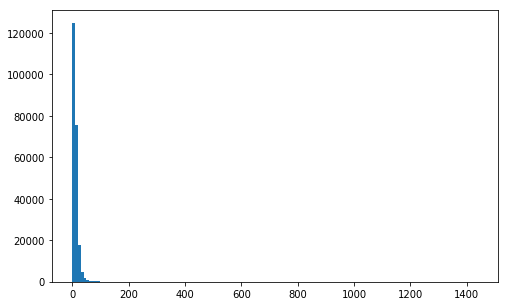

```python
binsize = 10
bins = np.arange(0, df_clean['duration_min'].max()+binsize, binsize)

plt.figure(figsize=[8, 5])

plt.hist(data = df_clean, x = 'duration_min', bins=bins);
```

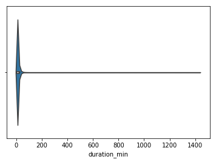

```python
sb.violinplot(data = df_clean, x = 'duration_min');
```

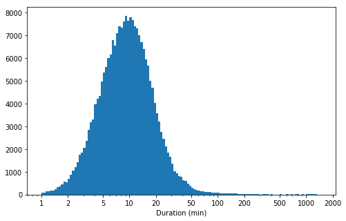

```python
# there's a long tail in the distribution, so let's put it on a log scale instead
log_binsize = 0.025
bins = 10 ** np.arange(0, np.log10(df_clean['duration_min'].max())+log_binsize, log_binsize)

plt.figure(figsize=[8, 5]);
plt.hist(data = df_clean, x = 'duration_min', bins = bins);
plt.xscale('log');
plt.xticks([1, 2, 5, 10, 20, 50, 100, 200, 500, 1000, 2000], [1, 2, 5, 10, 20, 50, 100, 200, 500, 1000, 2000]);
plt.xlabel('Duration (min)');
```

```python
# Leave record with duration_min < 100 min
df_clean = df_clean[df_clean['duration_min'] <= 100]
df_clean.info()
```

```
<class 'pandas.core.frame.DataFrame'>
Int64Index: 226804 entries, 4 to 239110
Data columns (total 20 columns):
duration_sec               226804 non-null int64
start_time                 226804 non-null datetime64[ns]
end_time                   226804 non-null datetime64[ns]
start_station_id           226804 non-null float64
start_station_name         226804 non-null object
start_station_latitude     226804 non-null float64
start_station_longitude    226804 non-null float64
end_station_id             226804 non-null float64
end_station_name           226804 non-null object
end_station_latitude       226804 non-null float64
end_station_longitude      226804 non-null float64
bike_id                    226804 non-null int64
user_type                  226804 non-null object
member_birth_year          226804 non-null int64
member_gender              226804 non-null object
bike_share_for_all_trip    226804 non-null object
start_time_dayofweek       226804 non-null category
start_time_hour            226804 non-null int64
member_age                 226804 non-null int64
duration_min               226804 non-null float64
dtypes: category(1), datetime64[ns](2), float64(7), int64(5), object(5)
memory usage: 34.8+ MB
```

```python
df_clean['member_age'].describe()
```

```
count    226804.000000
mean         34.137008
std           9.954496
min          18.000000
25%          27.000000
50%          32.000000
75%          39.000000
max         141.000000
Name: member_age, dtype: float64
```

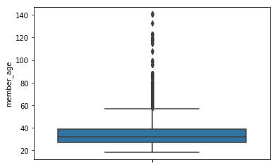

```python
sb.boxplot(data = df_clean, y = 'member_age');
```

```python
# removing outliners.
df_clean = df_clean[df_clean['member_age'] <= 60]
```

```python
df_clean.head()
```

|  | duration_sec | start_time | end_time | start_station_id | start_station_name | start_station_latitude | start_station_longitude | end_station_id | end_station_name | end_station_latitude | end_station_longitude | bike_id | user_type | member_birth_year | member_gender | bike_share_for_all_trip | start_time_dayofweek | start_time_hour | member_age | duration_min |
| --- | --- | --- | --- | --- | --- | --- | --- | --- | --- | --- | --- | --- | --- | --- | --- | --- | --- | --- | --- | --- |
| 4 | 1128 | 2019-04-30 23:59:04.739 | 2019-05-01 00:17:53.091 | 124.0 | 19th St at Florida St | 37.760447 | -122.410807 | 5.0 | Powell St BART Station (Market St at 5th St) | 37.783899 | -122.408445 | 877 | Subscriber | 1973 | Male | No | Tue | 23 | 46 | 18.800000 |
| 5 | 1388 | 2019-04-30 23:53:05.982 | 2019-05-01 00:16:14.313 | 243.0 | Bancroft Way at College Ave | 37.869360 | -122.254337 | 247.0 | Fulton St at Bancroft Way | 37.867789 | -122.265896 | 3234 | Customer | 1997 | Male | No | Tue | 23 | 22 | 23.133333 |
| 6 | 920 | 2019-04-30 23:57:56.340 | 2019-05-01 00:13:16.454 | 202.0 | Washington St at 8th St | 37.800754 | -122.274894 | 220.0 | San Pablo Ave at MLK Jr Way | 37.811351 | -122.273422 | 3262 | Subscriber | 1976 | Male | Yes | Tue | 23 | 43 | 15.333333 |
| 7 | 725 | 2019-04-30 23:56:11.219 | 2019-05-01 00:08:16.915 | 44.0 | Civic Center/UN Plaza BART Station (Market St ... | 37.781074 | -122.411738 | 121.0 | Mission Playground | 37.759210 | -122.421339 | 2706 | Customer | 1973 | Male | No | Tue | 23 | 46 | 12.083333 |
| 8 | 488 | 2019-04-30 23:59:00.660 | 2019-05-01 00:07:08.975 | 21.0 | Montgomery St BART Station (Market St at 2nd St) | 37.789625 | -122.400811 | 64.0 | 5th St at Brannan St | 37.776754 | -122.399018 | 860 | Subscriber | 1986 | Male | No | Tue | 23 | 33 | 8.133333 |

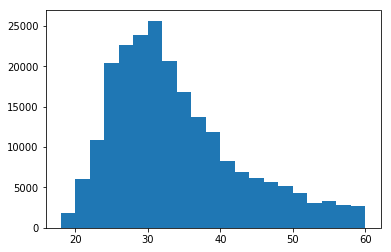

```python
binsize = 2
bins = np.arange(18, df_clean['member_age'].max()+binsize, binsize)
plt.hist(data = df_clean, x = 'member_age', bins = bins);
```

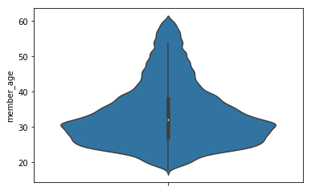

```python
sb.violinplot(data = df_clean, y = 'member_age');
```

```python
# save cleaned data
df_clean.to_csv('clean_master_file.csv', index=False)
```

```python
default_color = sb.color_palette()[0]
```

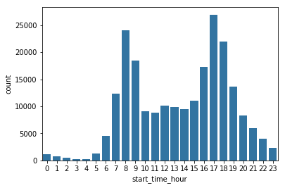

```python
sb.countplot(data = df_clean, x = 'start_time_hour', color = default_color);
```

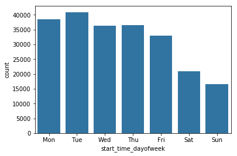

```python
sb.countplot(data = df_clean, x = 'start_time_dayofweek', color = default_color);
```

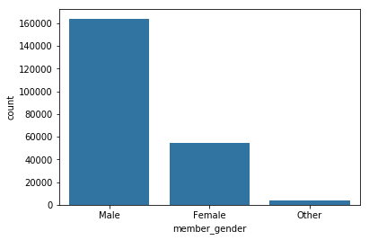

```python
sb.countplot(data = df_clean, x = 'member_gender', color = default_color);
```

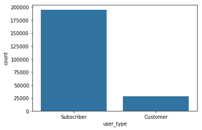

```python
sb.countplot(data = df_clean, x = 'user_type', color = default_color);
```

```python
all_numeric_vars = ['duration_sec', 'start_time', 'end_time', 'start_station_id', 'start_station_latitude', 'start_station_longitude', 'end_station_id', 'end_station_latitude',
'end_station_longitude', 'bike_id', 'member_birth_year', 'member_age', 'duration_min']
numeric_vars = ['duration_min', 'member_age']
categoric_vars = ['start_time_dayofweek', 'start_time_hour', 'member_gender', 'user_type']
```

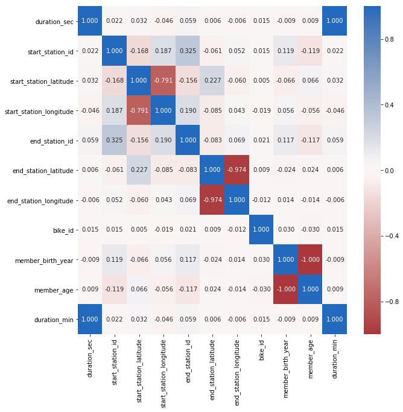

```python
#correlation plot
plt.figure(figsize = [10, 10])
sb.heatmap(df_clean[all_numeric_vars].corr(), annot = True, fmt = '.3f', cmap = 'vlag_r', center = 0);
```

From the above plot we can see that there are few variables which are highly correlated to some other variables either having positive correlation or negative correlation.

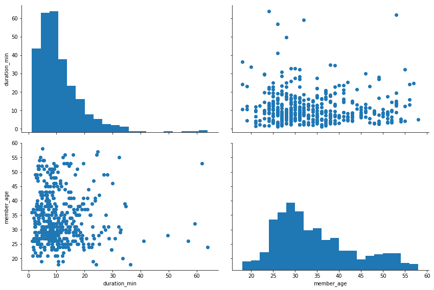

```python
# plot matrix: sample 500 records so that plots are clearer and
# they render faster

samples = np.random.choice(df_clean.shape[0], 500, replace = False)
samp = df_clean.loc[samples,:]

g = sb.PairGrid(data = samp, vars = numeric_vars, height = 4, aspect = 1.5)
g = g.map_diag(plt.hist, bins = 20);
g.map_offdiag(plt.scatter);
```

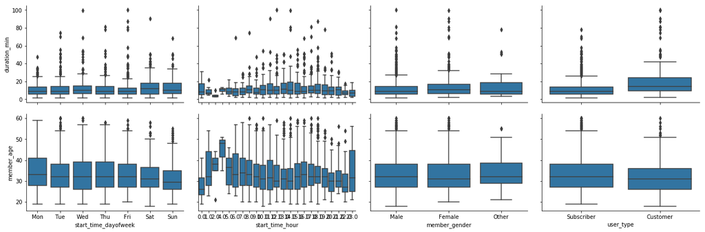

```python
# plot matrix of numeric features against categorical features.
# can use a larger sample since there are fewer plots and they're simpler in nature.

samples = np.random.choice(df_clean.shape[0], 2000, replace = False);
samp = df_clean.loc[samples, :];

def boxgrid(x, y, **kwargs):
    """ Quick hack for creating box plots with seaborn's PairGrid. """
    default_color = sb.color_palette()[0];
    sb.boxplot(x, y, color = default_color);

plt.figure(figsize = [15, 15]);
g = sb.PairGrid(data = samp, y_vars = ['duration_min', 'member_age'], x_vars = categoric_vars, height = 3, aspect = 1.5);
g.map(boxgrid);
```

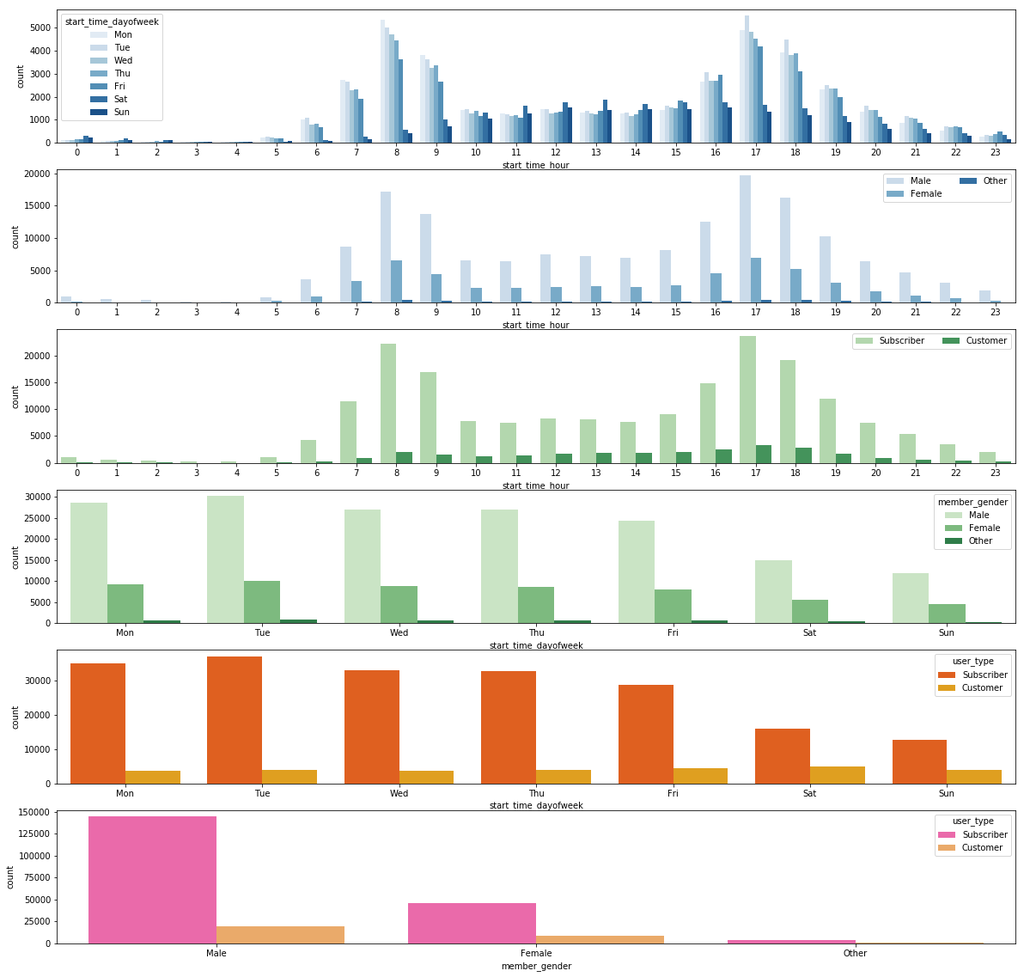

```python
plt.figure(figsize = [20, 20]);


plt.subplot(6, 1, 1);
sb.countplot(data = df_clean, x = 'start_time_hour', hue = 'start_time_dayofweek', palette = 'Blues');


ax = plt.subplot(6, 1, 2);
sb.countplot(data = df_clean, x = 'start_time_hour', hue = 'member_gender', palette = 'Blues');
ax.legend(ncol = 2); # re-arrange legend to reduce overlapping


ax = plt.subplot(6, 1, 3);
sb.countplot(data = df_clean, x = 'start_time_hour', hue = 'user_type', palette = 'Greens');
ax.legend(loc = 1, ncol = 2); # re-arrange legend to remove overlapping

ax = plt.subplot(6, 1, 4);
sb.countplot(data = df_clean, x = 'start_time_dayofweek', hue = 'member_gender', palette = 'Greens');

ax = plt.subplot(6, 1, 5);
sb.countplot(data = df_clean, x = 'start_time_dayofweek', hue = 'user_type', palette = 'autumn');

ax = plt.subplot(6, 1, 6);

sb.countplot(data = df_clean, x = 'member_gender', hue = 'user_type', palette = 'spring');
```

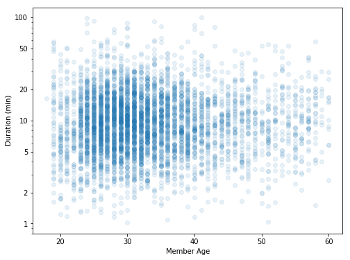

```python
# scatter plot of duration_min vs. member_age, with log transform on duration_min axis
samples = np.random.choice(df_clean.shape[0], 5000, replace = False)
samp = df_clean.loc[samples,:]

plt.figure(figsize = [8, 6]);
plt.scatter(data = samp, x = 'member_age', y = 'duration_min', alpha = 1/10);
#plt.xlim([0, 3.5])
plt.xlabel('Member Age');
plt.yscale('log');
plt.yticks([1, 2, 5, 10, 20, 50, 100], [1, 2, 5, 10, 20, 50, 100]);
plt.ylabel('Duration (min)');
```

```python
# compute the logarithm of price to make multivariate plotting easier
def log_trans(x, inverse = False):
    """ quick function for computing log and power operations """
    if not inverse:
        return np.log10(x)
    else:
        return np.power(10, x)

df_clean['log_duration_min'] = df_clean['duration_min'].apply(log_trans)
```

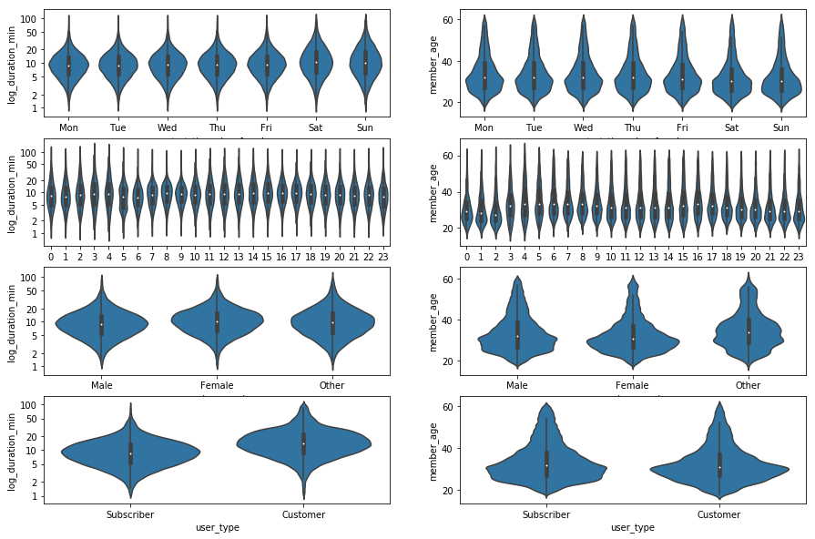

```python
# plot the categorical variables against duration_min and member_age again, this time
# with full data and variable transforms
fig, ax = plt.subplots(ncols = 2, nrows = 4 , figsize = [15,10])

for i in range(len(categoric_vars)):
    var = categoric_vars[i]
    sb.violinplot(data = df_clean, x = var, y = 'log_duration_min', ax = ax[i,0], color = default_color);
    ax[i,0].set_yticks(log_trans(np.array([1, 2, 5, 10, 20, 50, 100])));
    ax[i,0].set_yticklabels([1, 2, 5, 10, 20, 50, 100]);
    sb.violinplot(data = df_clean, x = var, y = 'member_age', ax = ax[i,1], color = default_color);
```

```python
age_flag1 = (df_clean['member_age'] < 40)
age_below_forty = df_clean.loc[age_flag1,:]

age_flag2 = (df_clean['member_age'] >= 40)
age_above_forty = df_clean.loc[age_flag2,:]
```

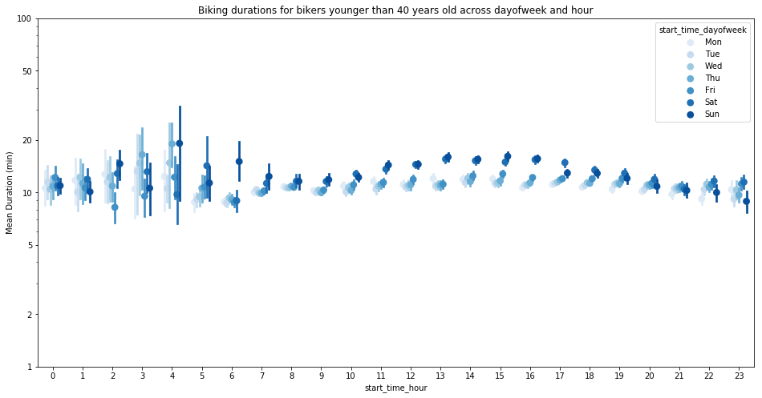

```python
fig = plt.figure(figsize = [16,8])

ax = sb.pointplot(data = age_below_forty, x = 'start_time_hour', y = 'duration_min', hue = 'start_time_dayofweek',
           palette = 'Blues', linestyles = '', dodge = 0.5);

plt.title('Biking durations for bikers younger than 40 years old across dayofweek and hour');
plt.ylabel('Mean Duration (min)');
plt.yscale('log');
plt.yticks([1, 2, 5, 10, 20, 50, 100], [1, 2, 5, 10, 20, 50, 100]);
ax.set_yticklabels([],minor = True);
```

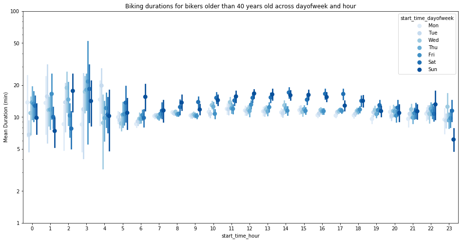

```python
fig = plt.figure(figsize = [16,8])

ax = sb.pointplot(data = age_above_forty, x = 'start_time_hour', y = 'duration_min', hue = 'start_time_dayofweek',
           palette = 'Blues', linestyles = '', dodge = 0.5);

plt.title('Biking durations for bikers older than 40 years old across dayofweek and hour');
plt.ylabel('Mean Duration (min)');
plt.yscale('log');
plt.yticks([1, 2, 5, 10, 20, 50, 100], [1, 2, 5, 10, 20, 50, 100]);
ax.set_yticklabels([],minor = True);
```

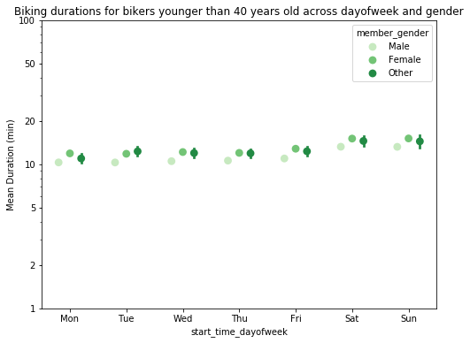

```python
fig = plt.figure(figsize = [8,6]);

ax = sb.pointplot(data = age_below_forty, x = 'start_time_dayofweek', y = 'duration_min', hue = 'member_gender',
                  palette = 'Greens', linestyles = '', dodge = 0.4);

plt.title('Biking durations for bikers younger than 40 years old across dayofweek and gender');
plt.ylabel('Mean Duration (min)');
plt.yscale('log');
plt.yticks([1, 2, 5, 10, 20, 50, 100], [1, 2, 5, 10, 20, 50, 100]);
ax.set_yticklabels([],minor = True);
```

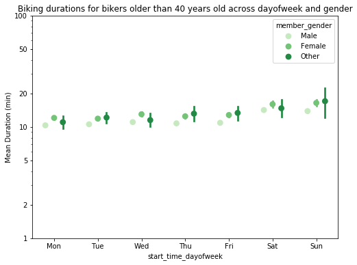

```python
fig = plt.figure(figsize = [8,6]);

ax = sb.pointplot(data = age_above_forty, x = 'start_time_dayofweek', y = 'duration_min', hue = 'member_gender',
                  palette = 'Greens', linestyles = '', dodge = 0.4);

plt.title('Biking durations for bikers older than 40 years old across dayofweek and gender');
plt.ylabel('Mean Duration (min)');
plt.yscale('log');
plt.yticks([1, 2, 5, 10, 20, 50, 100], [1, 2, 5, 10, 20, 50, 100]);
ax.set_yticklabels([],minor = True);
```

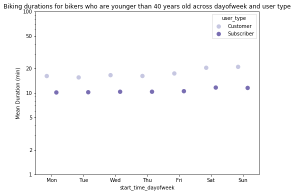

```python
fig = plt.figure(figsize = [8,6])
ax = sb.pointplot(data = age_below_forty, x = 'start_time_dayofweek', y = 'duration_min', hue = 'user_type',
           palette = 'Purples', linestyles = '', dodge = 0.3);
plt.title('Biking durations for bikers who are younger than 40 years old across dayofweek and user type');
plt.ylabel('Mean Duration (min)')
plt.yscale('log');
plt.yticks([1, 2, 5, 10, 20, 50, 100], [1, 2, 5, 10, 20, 50, 100]);
ax.set_yticklabels([],minor = True);
```

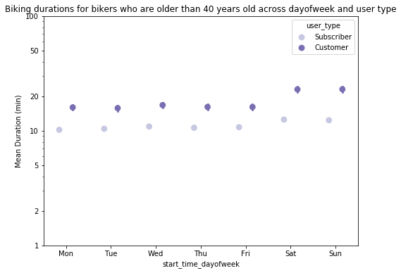

```python
fig = plt.figure(figsize = [8,6]);
ax = sb.pointplot(data = age_above_forty, x = 'start_time_dayofweek', y = 'duration_min', hue = 'user_type',
           palette = 'Purples', linestyles = '', dodge = 0.3);
plt.title('Biking durations for bikers who are older than 40 years old across dayofweek and user type');
plt.ylabel('Mean Duration (min)');
plt.yscale('log');
plt.yticks([1, 2, 5, 10, 20, 50, 100], [1, 2, 5, 10, 20, 50, 100]);
ax.set_yticklabels([],minor = True);
```

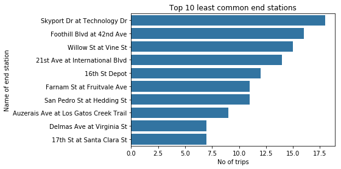

```python
neighbourhood_counts = df['end_station_name'].value_counts()
neighbourhood_order = neighbourhood_counts.index
sb.countplot(data = df, y = 'end_station_name', order = neighbourhood_order[-10:], color=default_color)
plt.xlabel('No of trips')
plt.ylabel('Name of end station')
plt.title('Top 10 least common end stations');
```

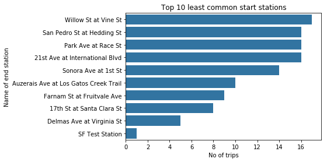

```python
neighbourhood_counts = df['start_station_name'].value_counts()
neighbourhood_order = neighbourhood_counts.index
sb.countplot(data = df, y = 'start_station_name', order = neighbourhood_order[-10:], color=default_color)
plt.xlabel('No of trips')
plt.ylabel('Name of end station')
plt.title('Top 10 least common start stations');
```

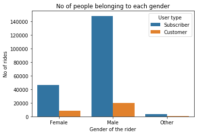

```python
sb.countplot(data=df, x='member_gender', hue='user_type');
plt.xlabel('Gender of the rider')
plt.ylabel('No of rides')
plt.title('No of people belonging to each gender')
plt.legend(title='User type');
```

We can see that most of the rides are. done by males

```python
df_clean.head()
```

|  | duration_sec | start_time | end_time | start_station_id | start_station_name | start_station_latitude | start_station_longitude | end_station_id | end_station_name | end_station_latitude | ... | bike_id | user_type | member_birth_year | member_gender | bike_share_for_all_trip | start_time_dayofweek | start_time_hour | member_age | duration_min | log_duration_min |
| --- | --- | --- | --- | --- | --- | --- | --- | --- | --- | --- | --- | --- | --- | --- | --- | --- | --- | --- | --- | --- | --- |
| 4 | 1128 | 2019-04-30 23:59:04.739 | 2019-05-01 00:17:53.091 | 124.0 | 19th St at Florida St | 37.760447 | -122.410807 | 5.0 | Powell St BART Station (Market St at 5th St) | 37.783899 | ... | 877 | Subscriber | 1973 | Male | No | Tue | 23 | 46 | 18.800000 | 1.274158 |
| 5 | 1388 | 2019-04-30 23:53:05.982 | 2019-05-01 00:16:14.313 | 243.0 | Bancroft Way at College Ave | 37.869360 | -122.254337 | 247.0 | Fulton St at Bancroft Way | 37.867789 | ... | 3234 | Customer | 1997 | Male | No | Tue | 23 | 22 | 23.133333 | 1.364238 |
| 6 | 920 | 2019-04-30 23:57:56.340 | 2019-05-01 00:13:16.454 | 202.0 | Washington St at 8th St | 37.800754 | -122.274894 | 220.0 | San Pablo Ave at MLK Jr Way | 37.811351 | ... | 3262 | Subscriber | 1976 | Male | Yes | Tue | 23 | 43 | 15.333333 | 1.185637 |
| 7 | 725 | 2019-04-30 23:56:11.219 | 2019-05-01 00:08:16.915 | 44.0 | Civic Center/UN Plaza BART Station (Market St ... | 37.781074 | -122.411738 | 121.0 | Mission Playground | 37.759210 | ... | 2706 | Customer | 1973 | Male | No | Tue | 23 | 46 | 12.083333 | 1.082187 |
| 8 | 488 | 2019-04-30 23:59:00.660 | 2019-05-01 00:07:08.975 | 21.0 | Montgomery St BART Station (Market St at 2nd St) | 37.789625 | -122.400811 | 64.0 | 5th St at Brannan St | 37.776754 | ... | 860 | Subscriber | 1986 | Male | No | Tue | 23 | 33 | 8.133333 | 0.910269 |

5 rows × 21 columns

```python
df_clean.head()
```

|  | duration_sec | start_time | end_time | start_station_id | start_station_name | start_station_latitude | start_station_longitude | end_station_id | end_station_name | end_station_latitude | ... | bike_id | user_type | member_birth_year | member_gender | bike_share_for_all_trip | start_time_dayofweek | start_time_hour | member_age | duration_min | log_duration_min |
| --- | --- | --- | --- | --- | --- | --- | --- | --- | --- | --- | --- | --- | --- | --- | --- | --- | --- | --- | --- | --- | --- |
| 4 | 1128 | 2019-04-30 23:59:04.739 | 2019-05-01 00:17:53.091 | 124.0 | 19th St at Florida St | 37.760447 | -122.410807 | 5.0 | Powell St BART Station (Market St at 5th St) | 37.783899 | ... | 877 | Subscriber | 1973 | Male | No | Tue | 23 | 46 | 18.800000 | 1.274158 |
| 5 | 1388 | 2019-04-30 23:53:05.982 | 2019-05-01 00:16:14.313 | 243.0 | Bancroft Way at College Ave | 37.869360 | -122.254337 | 247.0 | Fulton St at Bancroft Way | 37.867789 | ... | 3234 | Customer | 1997 | Male | No | Tue | 23 | 22 | 23.133333 | 1.364238 |
| 6 | 920 | 2019-04-30 23:57:56.340 | 2019-05-01 00:13:16.454 | 202.0 | Washington St at 8th St | 37.800754 | -122.274894 | 220.0 | San Pablo Ave at MLK Jr Way | 37.811351 | ... | 3262 | Subscriber | 1976 | Male | Yes | Tue | 23 | 43 | 15.333333 | 1.185637 |
| 7 | 725 | 2019-04-30 23:56:11.219 | 2019-05-01 00:08:16.915 | 44.0 | Civic Center/UN Plaza BART Station (Market St ... | 37.781074 | -122.411738 | 121.0 | Mission Playground | 37.759210 | ... | 2706 | Customer | 1973 | Male | No | Tue | 23 | 46 | 12.083333 | 1.082187 |
| 8 | 488 | 2019-04-30 23:59:00.660 | 2019-05-01 00:07:08.975 | 21.0 | Montgomery St BART Station (Market St at 2nd St) | 37.789625 | -122.400811 | 64.0 | 5th St at Brannan St | 37.776754 | ... | 860 | Subscriber | 1986 | Male | No | Tue | 23 | 33 | 8.133333 | 0.910269 |

5 rows × 21 columns

```python
# Adding Month, Day and Hour of tweets and retweets

df_clean['start_month'] = df_clean['start_time'].dt.month_name()
df_clean['start_day'] = df_clean['start_time'].dt.day_name()
df_clean['start_hour'] = df_clean['start_time'].dt.hour


df_clean['end_month'] = df_clean['end_time'].dt.month_name()
df_clean['end_day'] = df_clean['end_time'].dt.day_name()
df_clean['end_hour'] = df_clean['end_time'].dt.hour
```

```python
df_clean
```

[output not shown]

222660 rows × 27 columns

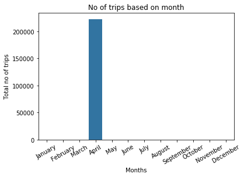

```python
x_marker = ['January', 'February', 'March', 'April', 'May', 'June', 'July', 'August', 'September', 'October',
            'November', 'December']
sb.countplot(data=df_clean, x='start_month', order=x_marker, color=default_color);
plt.xticks(rotation=30)
plt.title('No of trips based on month')
plt.xlabel('Months')
plt.ylabel('Total no of trips');
```

The above graph shows that the given dataset contains the. data only for the moth of april

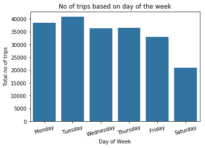

```python
x_marker = ['Monday', 'Tuesday', 'Wednesday', 'Thursday','Friday', 'Saturday']
sb.countplot(data=df_clean, x='start_day', order=x_marker, color=default_color);
plt.title('No of trips based on day of the week')
plt.xlabel('Day of Week')
plt.xticks(rotation=15)
plt.ylabel('Total no of trips');
```

```python
df_clean.to_csv('clean_master_file.csv', index=False)
```

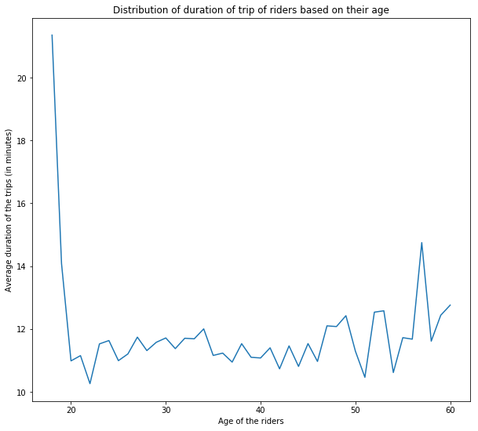

```python
plt.figure(figsize=(10,9))
sb.lineplot(data=df_clean[df_clean['member_age']<100], x='member_age', y='duration_min', err_style=None)
plt.xlabel('Age of the riders')
plt.ylabel('Average duration of the trips (in minutes)')
plt.title('Distribution of duration of trip of riders based on their age');
```

We can see that the highest duration of trips is for the age groups around 20, aslo it show. there is no one older than 60 is riding bike

```python
df_clean[df_clean['member_age']>60]
```

|  | duration_sec | start_time | end_time | start_station_id | start_station_name | start_station_latitude | start_station_longitude | end_station_id | end_station_name | end_station_latitude | ... | start_time_hour | member_age | duration_min | log_duration_min | start_month | start_day | start_hour | end_month | end_day | end_hour |
| --- | --- | --- | --- | --- | --- | --- | --- | --- | --- | --- | --- | --- | --- | --- | --- | --- | --- | --- | --- | --- | --- |

0 rows × 27 columns

[figure not shown]

```python
neighbourhood_counts = df['bike_id'].value_counts()
neighbourhood_order = neighbourhood_counts.index
plt.xlim(0,df['bike_id'].value_counts().max() + 1)
sb.countplot(data = df, y = 'bike_id', order = neighbourhood_order[0:15], color=default_color)
plt.xlabel('No of rides')
plt.ylabel('Bike ID')
plt.title('Top 10 most common bike models');
```

based on the graph. above we can see that bike model 3750 is the most used

```python
df_clean.head()
```

|  | duration_sec | start_time | end_time | start_station_id | start_station_name | start_station_latitude | start_station_longitude | end_station_id | end_station_name | end_station_latitude | ... | start_time_hour | member_age | duration_min | log_duration_min | start_month | start_day | start_hour | end_month | end_day | end_hour |
| --- | --- | --- | --- | --- | --- | --- | --- | --- | --- | --- | --- | --- | --- | --- | --- | --- | --- | --- | --- | --- | --- |
| 4 | 1128 | 2019-04-30 23:59:04.739 | 2019-05-01 00:17:53.091 | 124.0 | 19th St at Florida St | 37.760447 | -122.410807 | 5.0 | Powell St BART Station (Market St at 5th St) | 37.783899 | ... | 23 | 46 | 18.800000 | 1.274158 | April | Tuesday | 23 | May | Wednesday | 0 |
| 5 | 1388 | 2019-04-30 23:53:05.982 | 2019-05-01 00:16:14.313 | 243.0 | Bancroft Way at College Ave | 37.869360 | -122.254337 | 247.0 | Fulton St at Bancroft Way | 37.867789 | ... | 23 | 22 | 23.133333 | 1.364238 | April | Tuesday | 23 | May | Wednesday | 0 |
| 6 | 920 | 2019-04-30 23:57:56.340 | 2019-05-01 00:13:16.454 | 202.0 | Washington St at 8th St | 37.800754 | -122.274894 | 220.0 | San Pablo Ave at MLK Jr Way | 37.811351 | ... | 23 | 43 | 15.333333 | 1.185637 | April | Tuesday | 23 | May | Wednesday | 0 |
| 7 | 725 | 2019-04-30 23:56:11.219 | 2019-05-01 00:08:16.915 | 44.0 | Civic Center/UN Plaza BART Station (Market St ... | 37.781074 | -122.411738 | 121.0 | Mission Playground | 37.759210 | ... | 23 | 46 | 12.083333 | 1.082187 | April | Tuesday | 23 | May | Wednesday | 0 |
| 8 | 488 | 2019-04-30 23:59:00.660 | 2019-05-01 00:07:08.975 | 21.0 | Montgomery St BART Station (Market St at 2nd St) | 37.789625 | -122.400811 | 64.0 | 5th St at Brannan St | 37.776754 | ... | 23 | 33 | 8.133333 | 0.910269 | April | Tuesday | 23 | May | Wednesday | 0 |

5 rows × 27 columns